# Facets, Scales and Transformations

Rockefeller University, Bioinformatics Resource Centre

https://rockefelleruniversity.github.io/Plotting_In_R/

These exercises cover the Facets, Scales and Transformations of ggplot2 for [Plotting in R](https://rockefelleruniversity.github.io/Plotting_In_R/).

**Exercise 1** - **Facets**

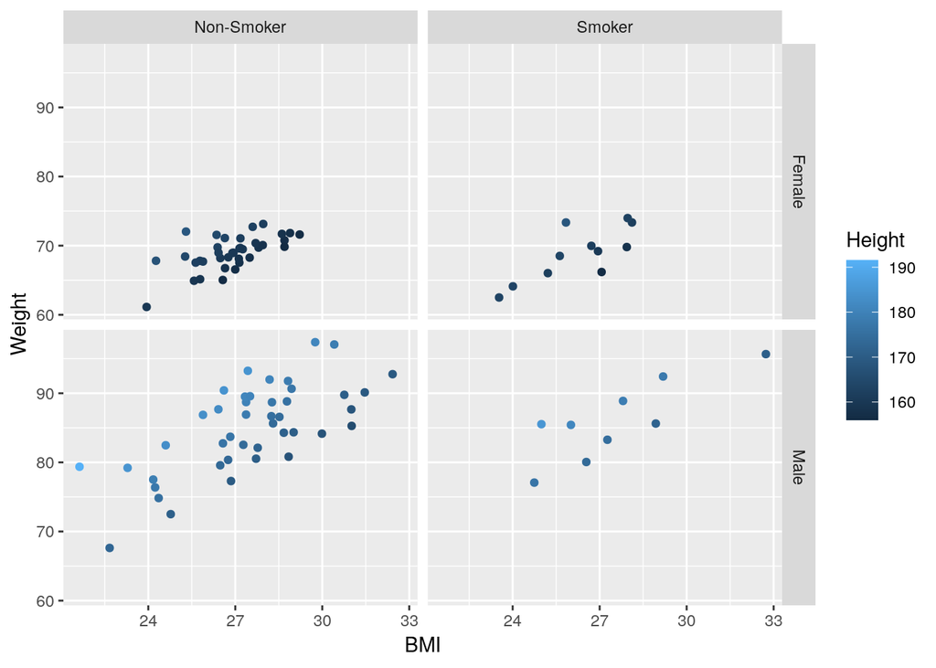

- Now reproduce the boxplots in exercise 8 (grouped by smoker, coloured by sex) but now include a separate facet for people of different age (using Age column).

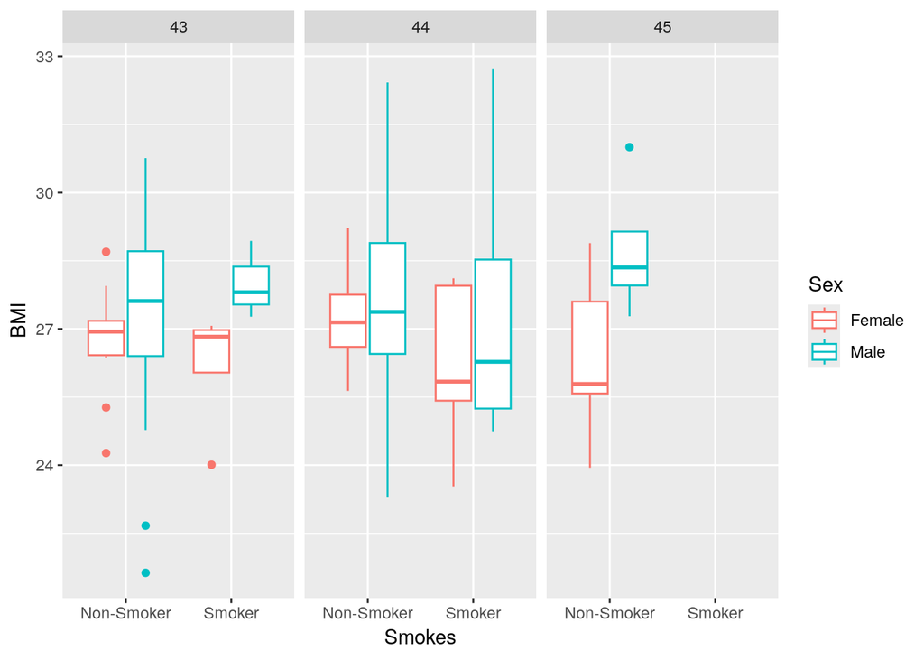

- Produce a similar boxplot of BMIs but this time group data by Sex, colour by Age and facet by Smoking status.

HINT - Discrete values such as in factors are used for categorical data.

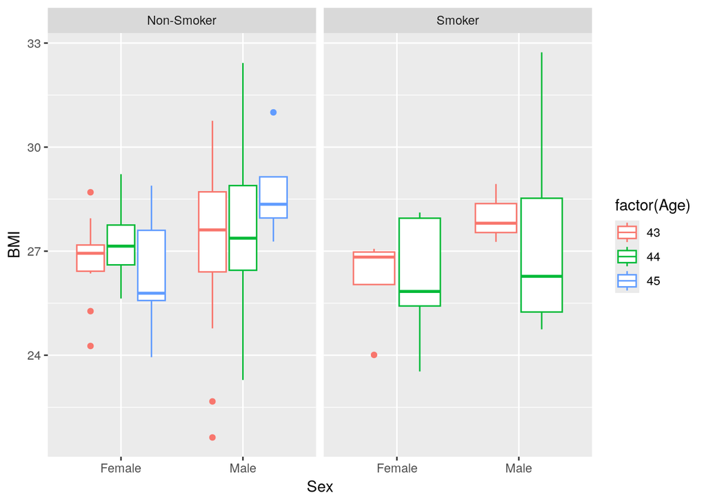

- Regenerate the solution to exercise 10 but this time using a violin plot.

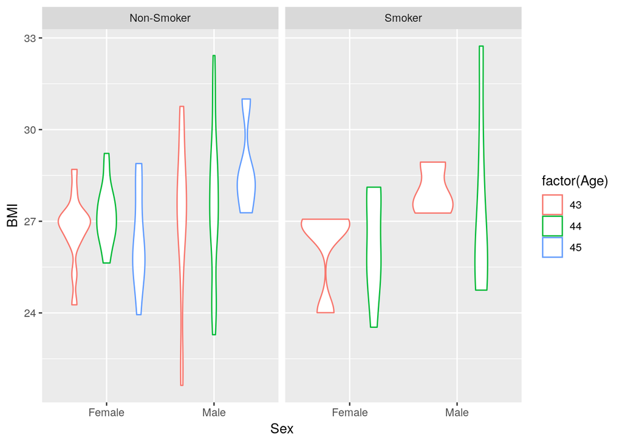

- Generate a separate density plot of BMI coloured by sex for each Grade,

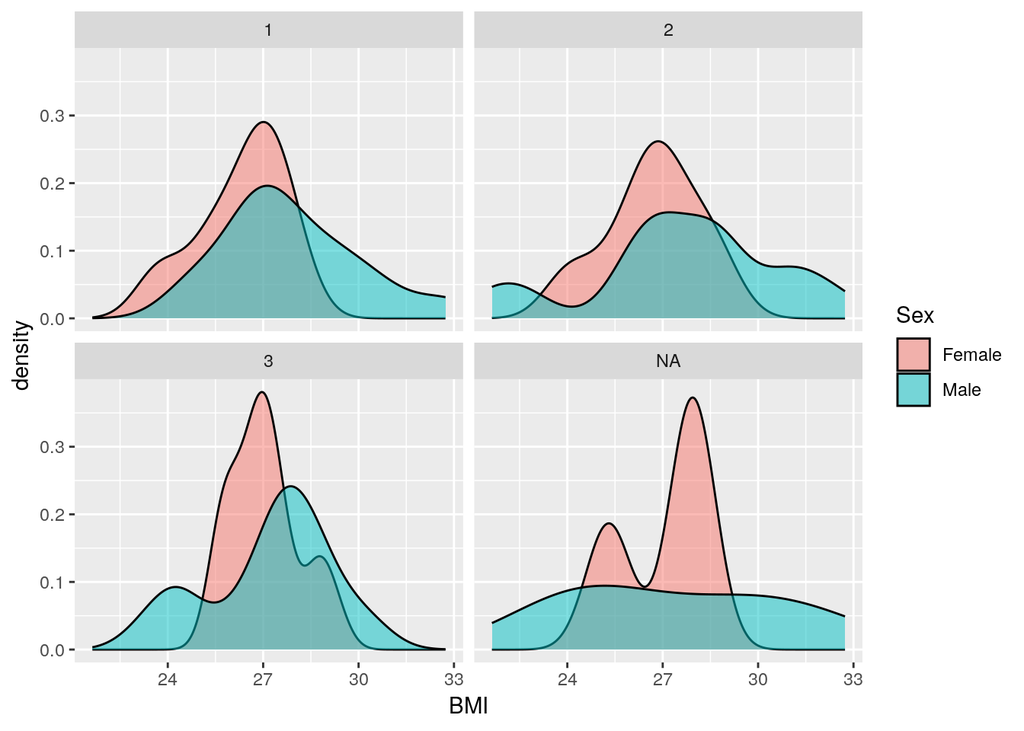

**Exercise 2** - **Scales**

1. Using the patient dataset from earlier, generate a scatter plot of BMI versus Weight

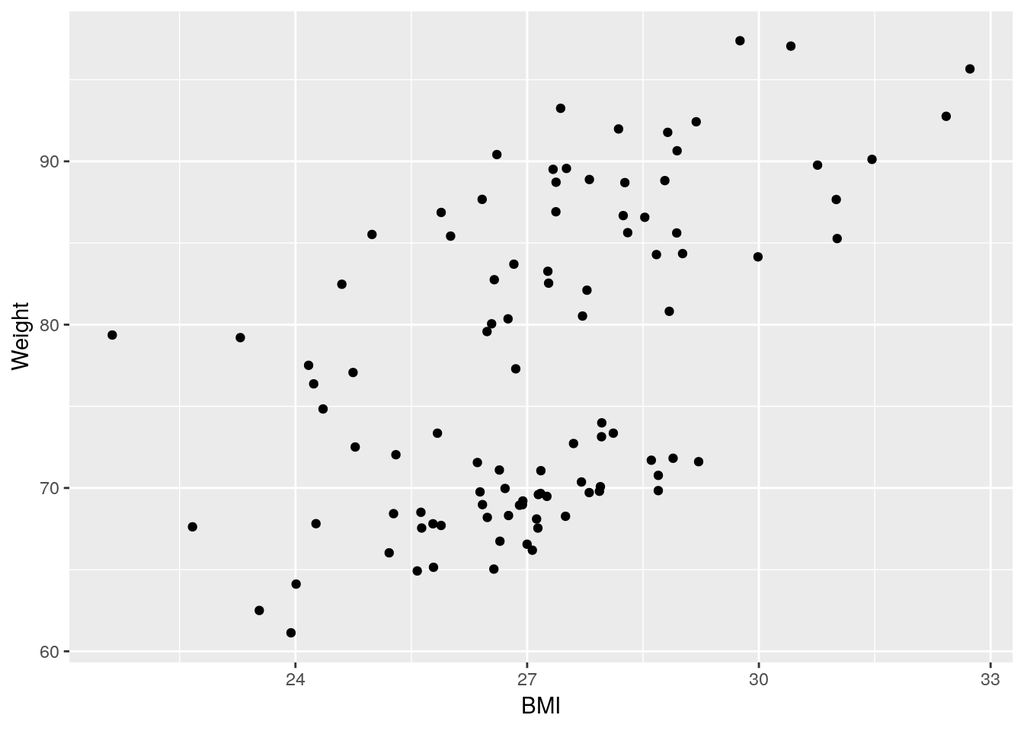

2. With the plot above, from exercise 1, adjust the BMI axis to show only labels for 20, 30, 40 and the weight axis to show breaks for 60 to 100 in steps of 5 as well as to specify units in y axis label.

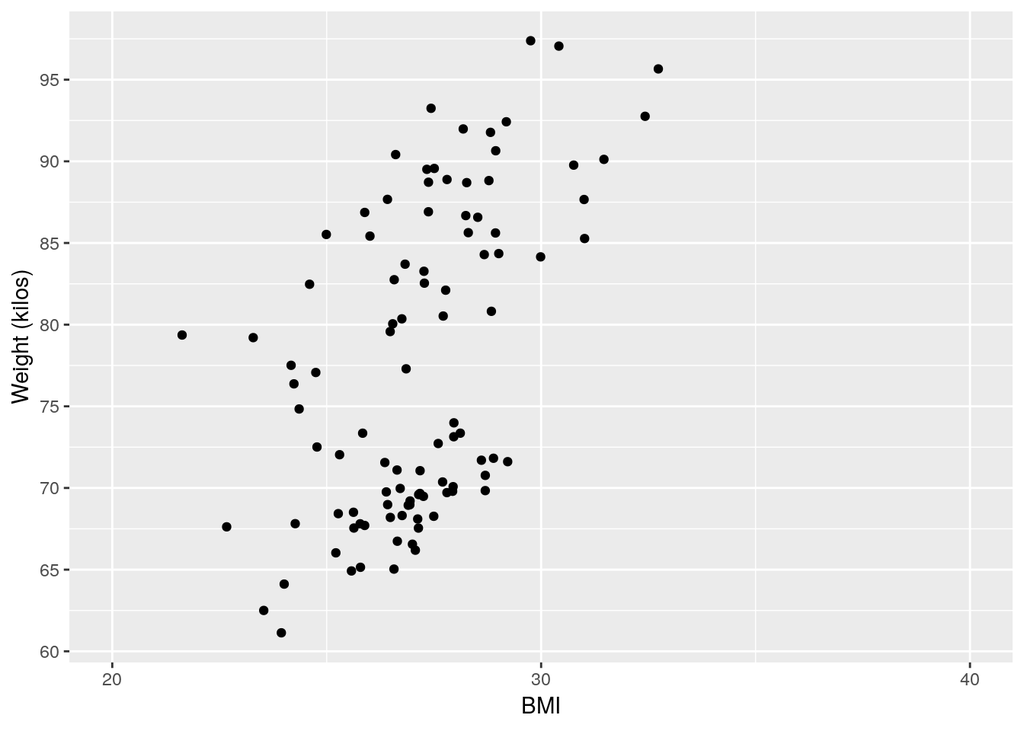

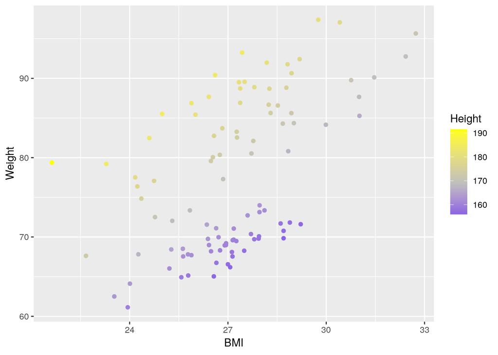

5. Adjust the plot from exercise 4 using scales to remove values greater than 180.

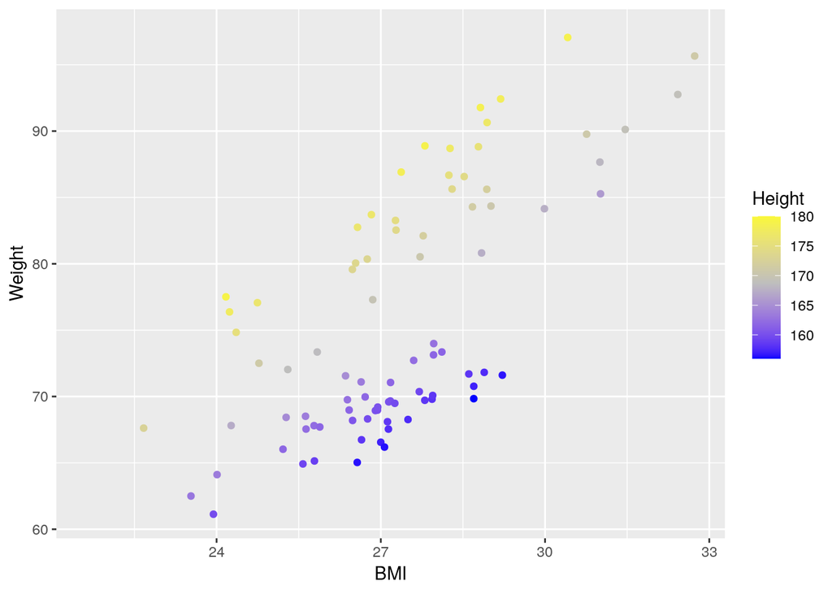

6. Adjust the scale legend from plot in exercise 4 to show only 75%, median and min values in scale legend.

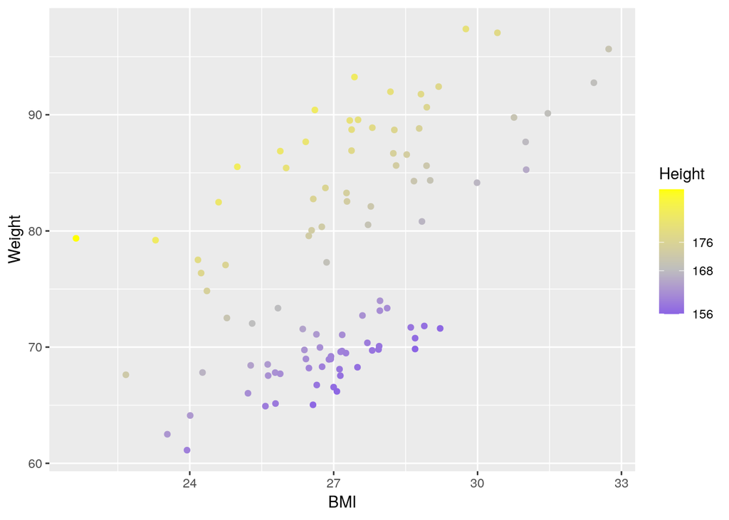

6. With the plot from exercise 4, create another scatterplot with Count variable mapped to transparency/alpha and size illustrating whether a person is overweight. Is there a better combination of aesthetic mappings?

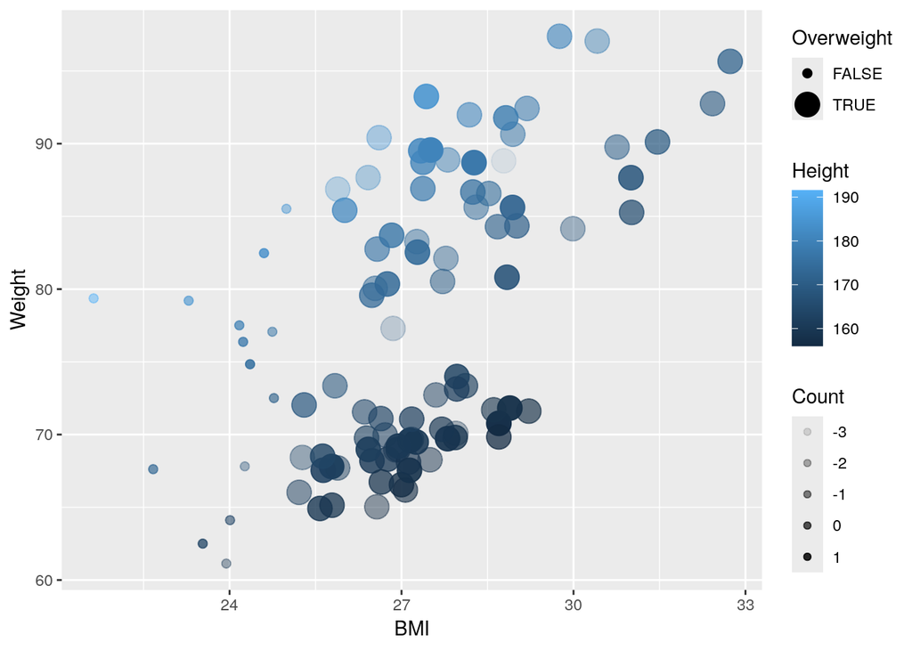

**Exercise 3** - **Statistics**

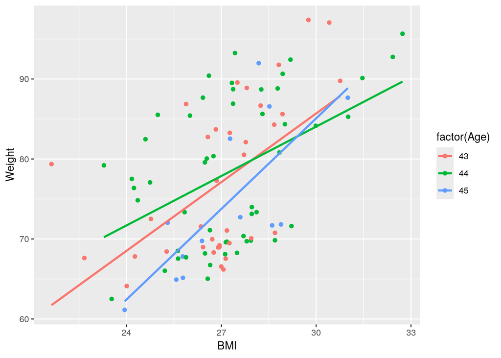